# Distributions of Random Variables

# 1 Normal Distribution

The normal distribution (Gaussian distribution) is a symmetric, bell-shaped distribution:

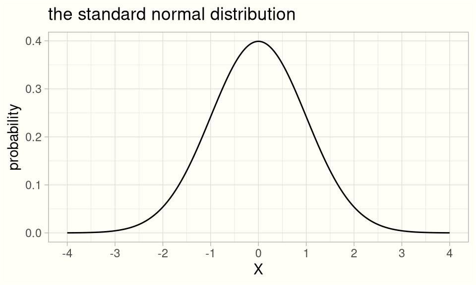

The exact form of the normal pdf is:

$$\text{pdf}(X) = \frac{1}{\sqrt{2\pi}\sigma} e^{-(X-\mu)^2/2\sigma^2}$$

Note in this expression there are only really two variables, $\mu$ and $\sigma$. These are the only parameters required to specify a normal curve (everything else in the expression is a constant). Changing $\mu$ shifts the curve left/right, and increasing $\sigma$ makes the curve wider.

If $X$ a normally distributed RV with mean $\mu$ and variance $\sigma^2$, you can use the shorthand notation:

$$X \sim \mathcal N(\mu, \sigma^2)$$

The distribution in the figure above is a specific case called the **standard normal distribution**. It has $\mu = 0$ and $\sigma = 1$.

You can find probabilities under the standard normal curve in R using the `pnorm()` function. It gives the cumulative probability that $X \leq k$.

E.g. to compute $\text{P}(X \leq 0)$:

```r
pnorm(0)
```

```
## [1] 0.5
```

To compute $\text{P}(-1 \leq X \leq 1)$:

```r
pnorm(1) - pnorm(-1)
```

```
## [1] 0.6826895
```

To compute $\text{P}(-2 \leq X \leq 2)$:

```r
pnorm(2) - pnorm(-2)
```

```
## [1] 0.9544997
```

And $\text{P}(-3 \leq X \leq 3)$:

```r
pnorm(3) - pnorm(-3)
```

```
## [1] 0.9973002
```

[figure not shown]

Consider a normally distributed random variable $X$ with $\mu = 10$ and $\sigma = 2$. What is the probability that $X$ is smaller than 7? One way to find this is by determining the $Z$-score.

The $Z$-score of an observation is defined as:

$$Z = \frac{X - \mu}{\sigma}$$

The $Z$-score describes how far away the value is from the mean, in units of standard deviation. In this case, with the observed value $X = 7$, the $Z$-score is $(7 - 10) / 2 = -1.5$. This means the observed value is 1.5 standard deviations to the left of the mean.

The $Z$-score is essentially a mapping of $X$ onto the standard normal distribution. Thus

$$\text{P}(X \leq 7) = \text{P}(Z \leq -1.5)$$

So to compute $\text{P}(X \leq 7)$ for $X \sim \mathcal N(10, 2^2)$, you can use `pnorm()`, plugging in the $Z$-score:

```r
pnorm(-1.5)
```

```
## [1] 0.0668072
```

Alternatively you can explicitly specify the parameters of normal distribution as additional arguments:

```r
pnorm(7, mean = 10, sd = 2)
```

```
## [1] 0.0668072
```

# 2 Uniform Distribution

The uniform distribution (rectangular distribution) can model a random variable which has an equal probability to take any value in a specified interval.

The uniform distribution is specified by two parameters, $a$ and $b$, which define the lower and upper bounds of the interval. The probability distribution is:

$$X \sim \mathcal U(a,b) \hspace{0.5cm} \longrightarrow \hspace{0.5cm} \text{pdf}(X) = \begin{cases} \frac{1}{b-a} & \text{for}\;\; x \in [a,b] \\ 0 & \text{otherwise} \end{cases}$$

The uniform distribution can be either discrete or continuous. In the discrete case, $X$ can take any integer value between $a$ and $b$ with equal probability, and in the continuous case, $X$ can take any real value between $a$ and $b$ with equal probability.

[figure not shown]

Expected value of a uniform distribution:

$$\text{E}[X] = \frac 12 (a+b)$$

Variance of a uniform distribution:

$$\text{Var}[X] = \frac{(b-a)^2-1}{12} \hspace{0.5cm} \text{(discrete)}$$

$$\text{Var}[X] = \frac{(b-a)^2}{12} \hspace{0.5cm} \text{(continuous)}$$

# 3 Bernoulli Distribution

The Bernoulli distribution can model a discrete random variable with a binary outcome (e.g. a single coin toss). Bernoulli random variables have the following features:

- one trial
- two outcomes (success/failure, 1/0, etc.)
- fixed probability of each outcome

The Bernoulli distribution is specified by one parameter, $p$, which describes the probability of a success ($X=1$).

The probability distribution of a Bernoulli RV is:

$$X \sim \text{Ber}(p) \hspace{0.5cm} \longrightarrow \hspace{0.5cm} \text{pmf}(X) = \begin{cases} p & X=1 \;\; \text{(success)} \\ 1-p & X=0 \;\; \text{(failure)}\end{cases}$$

Expected value of a Bernoulli RV:

$$\text{E}[X] = p$$

Variance of a Bernoulli RV:

$$\text{Var}[X] = p(1-p)$$

# 4 Binomial Distribution

The binomial distribution can model multiple occurrences of a Bernoulli process (e.g. several coin tosses). Binomial random variables have the following features:

- $n$ trials
- two outcomes (success/failure)
- fixed probability of each outcome across all trials
- trials must be independent

The binomial distribution is specified by two parameters, $n$ (number of trials) and $p$ (probability of success), and its probability distribution is:

$$X \sim \text{Bin}(n,p) \hspace{0.5cm} \longrightarrow \hspace{0.5cm} \text{P}(X = k) = \begin{pmatrix} n \\ k\end{pmatrix} p^k (1-p)^{n-k}$$

where $\big( \begin{smallmatrix} n \\ k \end{smallmatrix} \big)$ is called the **binomial coefficient**, and is another way of writing $\frac{n!}{k!(n-k)!}$.

Expected value of a binomial RV:

$$\text{E}[X] = np$$

Variance of a binomial RV:

$$\text{Var}[X] = np(1-p)$$

Note the Bernoulli distribution is a special case of the binomial with $n = 1$.

# 5 Poisson Distribution

The Poisson distribution can model a discrete random variable for events that occur a fixed number of times during a given interval. Poisson random variables have the following features:

- fixed rate at which events occur
- events cannot occur simultaneously
- events must occur independently

The Poisson distribution is specified by one parameter, $\lambda$, known as the **event rate**, which describes the average number of events in a given interval. The probability distribution is:

$$X \sim \text{Pois}(\lambda) \hspace{0.5cm} \longrightarrow \hspace{0.5cm} P(X = k) = \frac{e^{-\lambda} \lambda^k}{k!}$$

Expected value of a Poisson RV:

$$\text{E}[X] = \lambda$$

Variance of a Poisson RV:

$$\text{Var}[X] = \lambda$$